# Vectors

Ryan Mills

29/03/2021

# Vectors

**Lecture outline:**

1. What is a vector?
2. Creating a vector
3. Accessing a vector
4. Modifying a vector
5. Data types
6. Coercion of type & length
7. Element naming
8. Lists

## What is a vector?

So far in R, you have primarily worked with data frames, or specifically tibbles. Tibbles are a method of storing data where each row corresponds with an *observation*.

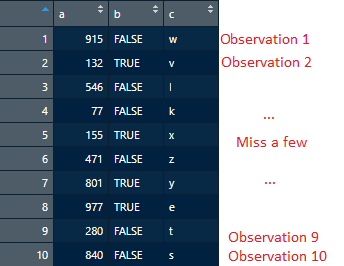

A tibble is a very useful object in this regard because it allows us to impose structure on the data. If we want to calculate across variable, the “one observation per row” rule ensures that we can do this easily. Similarly using **ggplot** or doing modelling is easier because each row correspond with one observation.

However, this structure also means that there is a loss of flexibility. Breaking the “one observation per row” rule is not possible in a tibble. This restricts the number of operations you can perform on a tibble. Once you move away from standard mathematical operators like +, -, * and /, the tibble becomes more restrictive. There are also a number of functions in base R that will not operate on tibbles and a number of packages that will not work with tibbles.

The alternative (or perhaps a work around) is the use of vectors. A vector is:

| **A collection of data with the same data type** |
| --- |

You will be forgiven for thinking this is quite a vague definition. You may be surprised to learn that there are three examples of vectors above (4 if you count the row numbers). For example, if we take column ‘a’:

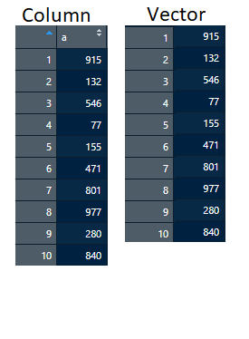

<sub>Figure 2: Comparison of a column and a vector</sub>

It is not a coincidence that they look remarkably similar. A column in a tibble is just a vector with structure placed on it. Specifically, the structure is that you have a name for that column (‘a’) and you have the rule that position 1 in column ‘a’ corresponds with position 1 in column ‘b’ and ‘c’.

You can think of this relationship as hierarchical. The tibble is a very ‘high-level’ object. It means that it takes the implementation of vectors and applies structure to it. Hence, it has a more narrow scope of purposes (in this case data analysis) but is highly stylised for those purposes. A vector has less structure, so it has a greater scope of purpose but is not stylised to a particular purpose.

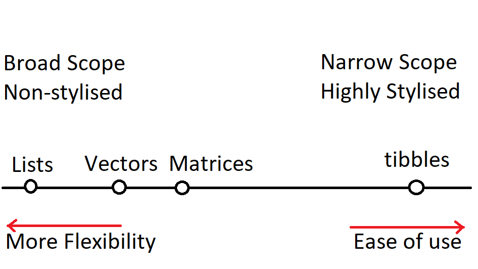

So let’s have a look at how R structures a vector:

```r
example_vector_1 <- c(1, 2, 3, 4, 5)
example_vector_1
```

```
## [1] 1 2 3 4 5
```

In the code above, we use the “combine” function `c()` to join several numbers together into a vector. First, let’s compare this to our implementation when using a tibble:

```r
example_tibble_1 <- tibble(
  `a` = c(1, 2, 3, 4, 5)
)
example_tibble_1
```

```
## # A tibble: 5 x 1
##       a
##   <dbl>
## 1     1
## 2     2
## 3     3
## 4     4
## 5     5
```

While the output looks vastly different in format, both the vector and tibble implementations share a number of similarities. In a tibble, we refer to each row as an observation. In a vector, each value is an **element**. The tibble has an ordering where the first row corresponds with the value 1, the second 2 and so on. The vector also has this natural ordering: the first element is 1, the second element is 2 and so on. Hence, we can visualise this vector as:

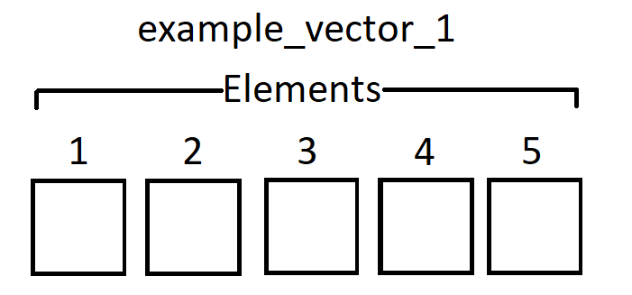

Each box represents a value, and the numbers 1, 2, 3, 4 and 5 represent the position of that value in the vector. Just as important as the number of elements is the data type of the element. Like a column in a tibble, a vector must only contain one “type” of data. Hence, if we fill the vector above:

This is a valid vector:

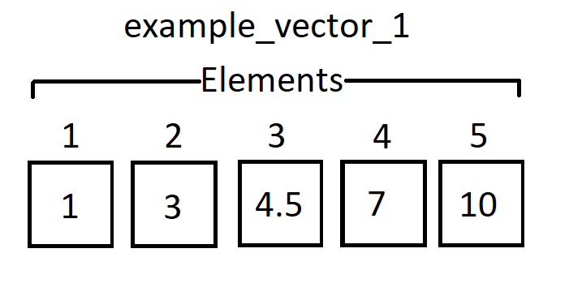

This is not a valid vector:

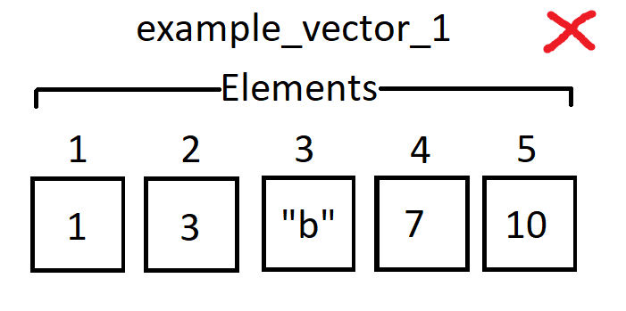

Hence we can consider a vector to be **a collection of n values with an identical data type.**

## Creating a Vector

Before one can utilise the immense power of a vector, one must first learn how to create a vector. You may (or may not) be surprised to learn that you have already built vectors before using two different methods in previous workshops. Here are some examples of methods, see if you can recall which ones you have used before:

```r
example_vector_1 <- c(1, 3, 5, 7, 9)
example_vector_1
```

```
## [1] 1 3 5 7 9
```

```r
example_vector_2 <- 1:9
example_vector_2
```

```
## [1] 1 2 3 4 5 6 7 8 9
```

```r
example_vector_3 <- seq(from = 1, to = 9, by = 2)
example_vector_3
```

```
## [1] 1 3 5 7 9
```

```r
example_vector_4 <- str_split('The Quick R-coder tripped over the flustered Excel user', ' ')
example_vector_4
```

```
## [[1]]
## [1] "The"       "Quick"     "R-coder"   "tripped"   "over"      "the"
## [7] "flustered" "Excel"     "user"
```

```r
example_vector_5 <- vector(mode = "numeric",
                    length = 5)
example_vector_5
```

```
## [1] 0 0 0 0 0
```

Three of these examples should look familiar (ideally the first three). Let’s breakdown briefly what each of these methods is doing:

### **c()**

The `c()` function is known as the “combine” function. It takes all the values that you specify and combine them into one function. You can specify individual elements such as `c(1, 3, 5, 7, 9)`, or you can also specify multiple vector to combine. For example, the two following outputs are equivalent:

```r
example_vector_6 <- c(1:3, 4:6, 7:9)
example_vector_7 <- 1:9


all(example_vector_6 == example_vector_7) #TRUE
```

```
## [1] TRUE
```

Note: you can test for equivalence in this case (and a lot of cases) by using the `==` operator. We will cover the `all()` operator later on, but it checks if **all elements** are equal between `example_vector_6` and `example_vector_7`.

The combine function is most frequently used when you have a known finite number of elements or vectors to combine.

### **Sequences**

The `seq()`function allows us to make sequences of numerical values in an interval with either a specified step size or number of elements. The following examples are all valid `seq()` calls:

```r
example_vector_8 <- seq(1, 5)
example_vector_8
```

```
## [1] 1 2 3 4 5
```

```r
example_vector_9 <- seq(from = 1, to = 7, by = 2.5)
example_vector_9
```

```
## [1] 1.0 3.5 6.0
```

```r
example_vector_10 <- seq(from = 1, to = 100, length.out = 7)
example_vector_10
```

```
## [1]   1.0  17.5  34.0  50.5  67.0  83.5 100.0
```

In the special case where you only need integers and your step size is one (i.e. `by = 1`), there is a short-hand operator denoted `:` . The `:` operator will allow you to make integer values between a start and an end point. Here are some examples:

```r
example_vector_11 <- 1:10
example_vector_12 <- seq(from = 1, to = 10,by = 1)

all(example_vector_11 == example_vector_12) # TRUE
```

```
## [1] TRUE
```

Hence you can use the short-hand operator for simple integer sequences, and use the `seq()` function when you need more complex sequences.

### Other methods

The fourth example used the function `str_split()` . There are many functions that will take an input and produce a vector, `str_split()` was used to showcase this. For the example above we put in 9 words, the function `str_split()` turned each word into an element of a vector, using the space (`" "`) character to determine where the splits should occur. You will have a wide variety of functions to create vectors and you can even make your own. For example, I have made the following function finds all prime numbers between 1 and n using the [Sieve of Eratosthenes](https://en.wikipedia.org/wiki/Sieve_of_Eratosthenes)

```r
# function name: find_primes(n)
# arguments:
# n - a positive integer value
# returns:
# A vector of prime numbers
# Purpose:
# To provide proof that the ancient Greek mathematicians were
# pretty smart. Also to show you how a function may return a vector from an input.
find_primes <- function(n){

  candidates <- 2:n

  for(i in 1:length(candidates)){

    number <- candidates[i]

    if (number == 0){
      next;
    }

    candidates[candidates %% number == 0 &
               candidates != number] <- 0
  }

  return(candidates[candidates != 0])
}

example_vector_13 <- find_primes(200)
length(example_vector_13)
```

```
## [1] 46
```

```r
example_vector_13
```

```
##  [1]   2   3   5   7  11  13  17  19  23  29  31  37  41  43  47  53  59  61  67
## [20]  71  73  79  83  89  97 101 103 107 109 113 127 131 137 139 149 151 157 163
## [39] 167 173 179 181 191 193 197 199
```

We can see that this vector is of length 46, which is because there are 46 prime numbers between 1 and 200. The output the function provides is a vector. There are many functions that will return a vector output in this fashion, and hopefully this serves as an example that you can make your own too!

### Vector()

The `vector()` function is the least common method you will likely use to create vectors. The `vector()` function allows you to create a vector before you populate it with values. For instance, if we want to create a vector of length 10 that is designed to accept numerical values we would use the following command:

```r
example_vector_14 <- vector(mode = "numeric",
                            length = 10)
example_vector_14
```

```
##  [1] 0 0 0 0 0 0 0 0 0 0
```

Notice the output is 10 zeros. This is because the default value for a numerical vector is zero. You can also create vectors for other types too like logical values and character strings:

```r
example_vector_15 <- vector(mode = "logical",
                            length = 10)

example_vector_16 <- vector(mode = "character",
                            length = 10)

example_vector_15
```

```
##  [1] FALSE FALSE FALSE FALSE FALSE FALSE FALSE FALSE FALSE FALSE
```

```r
example_vector_16
```

```
##  [1] "" "" "" "" "" "" "" "" "" ""
```

`example_vector_15` is a logical vector and takes on the default value of `FALSE` and `example_vector_16` is a character vector and takes on the default value of `""` (or empty string).

You might wonder why we would need to create a vector in this fashion, given we can just create a vector as we need one? Well to answer this, let’s take a look at another function:

```r
cumulative_sum <- function(x){
  output <- c()
  i <- 0
  while(i <= x){
    output <- c(output, sum(output) + i)
    i <- i + 1
  }

  return(output)
}

#bench::bench_time allows us to time an expression
bench::bench_time(example_vector_17 <- cumulative_sum(20000))
```

```
## process    real
##   25.4s   25.4s
```

```r
cumulative_sum_fast <- function(x){
  output <- vector(mode = "numeric",
                   length = x+1)
  i <- 1
  while(i <= x){
    output[i + 1] <- output[i] + i

    i <- i + 1
  }

  return(output)
}

bench::bench_time(example_vector_18 <- cumulative_sum_fast(20000))
```

```
## process    real
##       0  7.71ms
```

**Exercises:**

1. Using the `seq()` function and the `**` (square or ^2) command, create a vector that contains 1<sup>2</sup> , 2<sup>2</sup> , 3<sup>2</sup> , …, 10<sup>2</sup>
2. Using the `:` operator, create the same vector as above

For the next two exercises, we will use the `rep()` function.

1. Look up the `rep()` (repeat) function. Using this function, create a vector that repeats the sequence 1, 2, 3, 4 five times. Hint: you’ll want to use seq (or `:` ) and rep to do this
2. Using `rep()` , create a vector that repeats each of the numbers 1, 2, 3, 4 five times in a row? Hint: look at the `each` argument in rep.

## Accessing a vector

In dplyr when working with a tibble, you access a specific observation (or row) using the following command:

```r
example_tibble_2 <-
  tibble(
    `a` = c(10, 20, 30, 40, 50),
    `b` = c(TRUE, TRUE, TRUE, FALSE, FALSE),
    `c` = c('Columns','are','just','wannabe','vectors.')
  )

example_tibble_2 %>%
  slice(1)
```

```
## # A tibble: 1 x 3
##       a b     c
##   <dbl> <lgl> <chr>
## 1    10 TRUE  Columns
```

```r
# Output:

# A tibble: 1 x 3
#       a b     c
#   <dbl> <lgl> <chr>
# 1    10 TRUE  Columns
```

How can we interpret the above? Well we can imagine the `slice()` function as “slicing a piece from the cake”. You can slice a single slab (one observation) or be greedy and take most of it like so:

```r
example_tibble_2 %>%
  slice(1:4)
```

```
## # A tibble: 4 x 3
##       a b     c
##   <dbl> <lgl> <chr>
## 1    10 TRUE  Columns
## 2    20 TRUE  are
## 3    30 TRUE  just
## 4    40 FALSE wannabe
```

```r
# You can keep that last crumb
```

The approach used here is not that different to how you access elements in a vector. There is a slight syntax difference but beyond that the process is quite similar. Let’s replicate the data frame above as vectors and use an equivalent approach:

```r
vector_a <- c(10, 20, 30, 40, 50)
vector_b <- c(TRUE, TRUE, TRUE, FALSE, FALSE)
vector_c <- c('Columns','are','just','wannabe','vectors.')

# Retrive the first row ("observation")
vector_a[1]
```

```
## [1] 10
```

```r
vector_b[1]
```

```
## [1] TRUE
```

```r
vector_c[1]
```

```
## [1] "Columns"
```

Hopefully you can see the parallels between the two methods. If you want to retrieve multiple elements at once, the same process is followed as the example above:

```r
vector_a[1:4]
```

```
## [1] 10 20 30 40
```

```r
vector_b[1:4]
```

```
## [1]  TRUE  TRUE  TRUE FALSE
```

```r
vector_c[1:4]
```

```
## [1] "Columns" "are"     "just"    "wannabe"
```

There are some important points here:

- Indexes (i.e. positions) for vectors start at 1. This is the same for tibbles. This may seem obvious but if you use other languages they do quite often start at 0 rather than 1.
- If you supply a decimal number rather than an integer, the decimal portion of the number you specify will be removed. For example:

```r
vector_a[c(2.5,3.5)]
```

```
## [1] 20 30
```

Notice that it has accessed element 2 (20) and element 3 (30)? I would not recommend using decimal numbers to access vectors - there is no real reason why this functionality needs to exist.

If you try to access an element that does not exist in the vector (i.e. is larger than the length of the vector), R will return an `NA` (stands for “Not available”)

```r
vector_a[6]
```

```
## [1] NA
```

This is also quite different to all other programming languages and it is something you need to watch for. R will not explicitly tell you if your indexing is incorrect.

A concept that is a little bit more difficult to understand is **negative indexing**. A negative index is a way of telling R that you want to access all the elements in the vector except for the elements you have specified as negative. Let’s cement this by starting with a dplyr example:

```r
example_tibble_2 %>%
  slice(-1)
```

```
## # A tibble: 4 x 3
##       a b     c
##   <dbl> <lgl> <chr>
## 1    20 TRUE  are
## 2    30 TRUE  just
## 3    40 FALSE wannabe
## 4    50 FALSE vectors.
```

Notice how it removes the first observation and keeps the other four? This command is basically you saying to R, “Return all observations except for the observation 1”. Vectors work in exactly the same fashion:

```r
vector_a[-1]
```

```
## [1] 20 30 40 50
```

Just like the tibble, this command removes the first element from `vector_a`

You can also remove multiple elements at the same time. Let’s see how this works with a tibble

```r
example_tibble_2 %>%
  slice(-(2:4))
```

```
## # A tibble: 2 x 3
##       a b     c
##   <dbl> <lgl> <chr>
## 1    10 TRUE  Columns
## 2    50 FALSE vectors.
```

**Question: Can you figure out why I needed to put a bracket around the** `2:4` ? What do you think would happen if I used `-2:4` instead?

Vectors work in exactly the same fashion:

```r
vector_a[-(2:4)]
```

```
## [1] 10 50
```

The final concept we need to go through is logical indexing. Logical indexing is an alternative way of accessing vectors (or even tibbles). Let’s start with dplyr first. Note that when using logical indexing with a tibble, we no longer use the `slice()` function and instead use the `filter()` function:

```r
example_tibble_2 %>%
  filter(c(
    TRUE,
    FALSE,
    FALSE,
    TRUE,
    TRUE
  ))
```

```
## # A tibble: 3 x 3
##       a b     c
##   <dbl> <lgl> <chr>
## 1    10 TRUE  Columns
## 2    40 FALSE wannabe
## 3    50 FALSE vectors.
```

What have I done here? I have told the filter function to evaluate TRUE for the first observation, FALSE for the second and third, and TRUE for the fourth and fifth. This works in exactly the same way for vectors:

```r
vector_a[
  c(TRUE,
    FALSE,
    FALSE,
    TRUE,
    TRUE)
]
```

```
## [1] 10 40 50
```

Directly specifying the TRUE and FALSE values is not particularly useful beyond being an example. However, we can do some really powerful things with the logical indexing. For example, say we want to return all observations/elements in column`'c'/vector_c` where `'a'`/`vector_a` is not divisible by 20. We can do this in the following way:

```r
example_tibble_2 %>%
  filter(`a` %% 20 != 0)
```

```
## # A tibble: 3 x 3
##       a b     c
##   <dbl> <lgl> <chr>
## 1    10 TRUE  Columns
## 2    30 TRUE  just
## 3    50 FALSE vectors.
```

```r
vector_c[vector_a %% 20 != 0]
```

```
## [1] "Columns"  "just"     "vectors."
```

What are we doing here? Let’s break it down. When we write `vector_a %% 20 != 0` , this returns a TRUE or FALSE value for each element in `vector_a` . Hence, when we specify this value, R is evaluating the following conditions:

```r
vector_a[1] %% 20 != 0
```

```
## [1] TRUE
```

```r
vector_a[2] %% 20 != 0
```

```
## [1] FALSE
```

```r
vector_a[3] %% 20 != 0
```

```
## [1] TRUE
```

```r
vector_a[4] %% 20 != 0
```

```
## [1] FALSE
```

```r
vector_a[5] %% 20 != 0
```

```
## [1] TRUE
```

We don’t have to specify each of those five conditions separately, we can just write `vector_a %% 20 != 0` and it performs the same operations. The operation `vector_a %% 20 != 0` returns `[1] TRUE FALSE TRUE FALSE TRUE` and hence we keep the first, third and fifth element.

You an also combine logical conditions together. For instance, if we wanted to also check if `vector_b` was equal to TRUE, we could link the logical conditions using a `&` (or AND) symbol:

```r
example_tibble_2 %>%
  filter(`a` %% 20 != 0 &
         `b` == TRUE)
```

```
## # A tibble: 2 x 3
##       a b     c
##   <dbl> <lgl> <chr>
## 1    10 TRUE  Columns
## 2    30 TRUE  just
```

```r
vector_c[vector_a %% 20 != 0 & vector_b == TRUE]
```

```
## [1] "Columns" "just"
```

As a final aside, note that we can retrieve the underlying vector from the tibble too. There are two ways of going about this:

```r
example_tibble_2$a
```

```
## [1] 10 20 30 40 50
```

```r
example_tibble_2 %>%
  select(`a`) %>%
  pull()
```

```
## [1] 10 20 30 40 50
```

The commands are equivalent. The `pull()` function is designed to “pull” the vector out from the column. The former is a lot easier to write, and you don’t have to remember to use `select()` before using the `pull()` . The latter reads easier, but is tedious to write. Which one you use is a matter of personal preference - the latter is probably less commonly used because not a lot of people know about it.

**Exercises:**

1. There are two primary ways to link logical conditions together. Above we use the `&` symbol. The other is the `|` (OR) symbol. Can you build logical index to evaluate if `vector_a` is equal to 20 `or` `vector_b` is `not` (`!` symbol) equal to TRUE.
2. What do you think will happen if we call the following function: `vector_b[-6]` ?
3. Consider the following vector:

```r
vector_d <- c(NA, NA, 2, 3, NA, 5)
```

The function `is.na()` can be used on a vector to detect the presence of the value `NA` . Write a logical condition that returns the elements of d that are not `NA`.

4. Recall above that I used the `all()` command. The `all()` command checks if all values evaluate to TRUE. Write a logical condition that returns `vector_c` if all elements in `vector_a` are divisible by 10. You will want to use the `%%` command and the `all()` command.

## Modifying a Vector

When it comes to vector modification, this is where the parallels with tibbles end. In tibbles, it is enforced that you must either replace all rows in a column, or use `if_else` conditions to select certain rows to replace. In a vector, you can replace individual elements, a subset of elements, or the whole vector.

Modifying a vector is a lot like accessing a vector, but we use the assignment operator `<-` to set the value. Now that we have some ideas of how vectors work, we’ll also begin with more complex data that requires specific actions. I’ll use an example from R (so you don’t have to keep writing these datasets out - brief oversight up till now).

```r
data(airquality)

head(airquality)
```

```
##   Ozone Solar.R Wind Temp Month Day
## 1    41     190  7.4   67     5   1
## 2    36     118  8.0   72     5   2
## 3    12     149 12.6   74     5   3
## 4    18     313 11.5   62     5   4
## 5    NA      NA 14.3   56     5   5
## 6    28      NA 14.9   66     5   6
```

Let’s retrieve the underlying vector from the ozone column

```r
ozone <- airquality %>%
  select(`Ozone`) %>%
  pull()

ozone
```

```
##   [1]  41  36  12  18  NA  28  23  19   8  NA   7  16  11  14  18  14  34   6
##  [19]  30  11   1  11   4  32  NA  NA  NA  23  45 115  37  NA  NA  NA  NA  NA
##  [37]  NA  29  NA  71  39  NA  NA  23  NA  NA  21  37  20  12  13  NA  NA  NA
##  [55]  NA  NA  NA  NA  NA  NA  NA 135  49  32  NA  64  40  77  97  97  85  NA
##  [73]  10  27  NA   7  48  35  61  79  63  16  NA  NA  80 108  20  52  82  50
##  [91]  64  59  39   9  16  78  35  66 122  89 110  NA  NA  44  28  65  NA  22
## [109]  59  23  31  44  21   9  NA  45 168  73  NA  76 118  84  85  96  78  73
## [127]  91  47  32  20  23  21  24  44  21  28   9  13  46  18  13  24  16  13
## [145]  23  36   7  14  30  NA  14  18  20
```

The explanation of the dataset is that these are “daily readings of the following air quality values from May 1 1973 (a Tuesday) to September 30 1973”. I’m not sure why they need to clarify that it starts on a Tuesday - does the ozone find Monday mornings rough too?

From our inspection of the head, you may have noticed that there are some `NA` values (missing values) in the variable. The technique you have used so far to handle `NA` values is to use `na.rm = TRUE` when it is available as an argument, or use `` filter(!is.na(`ozone`)) `` .

Some people consider removing observations with `NA` in them to be a ‘data science sin’ because there may still be relevant information regarding those observations. One option they may choose instead is to replace the `NA` values with the `mean` (or average) value (incidentally, I am not one of these people).

**Exercise:** Let’s work through together how we might do this.

Recall that we can access the `NA` elements using the following call:

```r
ozone[is.na(ozone)]
```

```
##  [1] NA NA NA NA NA NA NA NA NA NA NA NA NA NA NA NA NA NA NA NA NA NA NA NA NA
## [26] NA NA NA NA NA NA NA NA NA NA NA NA
```

That gives us all elements that contain NA. We also know that the `mean()` function with the `na.rm = TRUE` option will give us the average. Using these two pieces of information, try to modify the NA elements to be equal to the mean. The general form of the solution will look like:

```r
#*vector*[*condition*] <- *new values*
```

Like when accessing a vector, we can also choose to change single values or multiple values. Examples of doing this are as follows:

```r
ozone[1] <- 41.5 #Originally 41

ozone[1:10] <- ozone[1:10] + 0.5

ozone[2:4] <- c(36, 12, 18)
```

All of these examples above area valid ways of modifying a vector. You can see that we can even refer to the values themselves as in the second example. One more thing we can do is modify all elements in the vector. Say for example, we wanted to express ozone in parts per million rather than parts per billion. To do this, we would divide the whole vector by 1000. This time we assign to the whole vector rather than part of a vector

```r
ozone <- ozone / 1000
```

**Exercises:**

1. What do you think would happen if we tried to use a negative index when modifying a vector? Say for example we were to do `ozone[-1] <- 3` . Note: if you run the command you will need to re-run the `pull()` command above.
2. What do you think will happen if we try to do `ozone[1] <- "41"` ? Try printing the `ozone` vector. What has happened?

## Data types

There are two key functions that are specifically designed to work with vectors in R. They are able to tell you about the key properties of a vector. The first is `length()` which gives you the number of elements in a vector. For example, try running `length(1:10)` and you should get the output `[1] 10` . `length()` is a very useful function when you are working with vectors of an unknown size.

The other function is `typeof()` and this is a function that can tell you the data type of the vector. Recall that I said that vectors must have the same data type. The function `typeof()` is a great way of telling if your data types are correct. For example, say you had the following vector:

```r
example_vector_16 <- c(TRUE, TRUE, FALSE, 1, FALSE)

typeof(example_vector_16)
```

```
## [1] "double"
```

We run `typeof()` on the vector and we get "`double"`. We could conclude that maybe we have an issue with one of our values. While this vector would still evaluate correctly as a logical condition, if we can’t guarantee that the numerical value is 1 or 0, then this would cause problems.

Let’s run through the 3 main “primitive” data types you will encounter in R and then we’ll talk about a concept called coercion.

### Numerical

You have already come across many examples of numerical vectors. Let’s briefly remind ourselves of a couple of ways of constructing numerical vectors:

```r
example_vector_17 <- c(1, 5, 9, 13)

example_vector_18 <- 1:5

example_vector_19 <- seq(from = 1, to = 10, length.out = 6)
```

The default type of numeric vector is a `double`. A double stands for “double precision”. They are designed to hold numbers with decimal values in them. There are some quirks to double’s that may catch you out. For example if we did the following calculation:

```r
example_num_1 <- sqrt(2) ^ 2
```

Our expectation is that `example_num_1` should have a `2` in it right? If you take the square root of the square, the operations cancel each other out. Well, let’s do an equality condition check on `example_num_1`

```r
example_num_1 == 2
```

```
## [1] FALSE
```

Uh oh, that didn’t work. According to this, `example_num_1` is not equal to 2. Why is this? Well this is because a `double` is an approximation. Each `double` has a fixed amount of memory available to it. In fact, R can store up to `1074` decimal digits in it - so it is fairly versatile, but in the case of `sqrt(2)` , this is an irrational number - so it essentially has an unknown number of digits. So how can we rectify this? Well we can use the function `near().` The `near()` function checks if two values are within an distance `a` of each other, e.g.

`abs(x - y) < a`

`a` by default is around `1e-8` , but you can also change this argument too, the default is usually a good value

```r
near(example_num_1, 2)
```

```
## [1] TRUE
```

```r
near(example_num_1, 2, tol = 1e-15)
```

```
## [1] TRUE
```

Machine precision issues are usually in the magnitude of `1e-16`

What if we want to directly specify that we are using vectors only? Well we can do this using two different methods:

```r
integer_vector_1 <- 1:10
typeof(integer_vector_1)
```

```
## [1] "integer"
```

```r
integer_vector_2 <- seq(1L, 10L, 1L)
typeof(integer_vector_2)
```

```
## [1] "integer"
```

```r
integer_vector_3 <- as.integer(c(5,10,15,20,25))
typeof(integer_vector_3)
```

```
## [1] "integer"
```

```r
# Note: The L symbol here means "Long"
```

The L symbol here means “Long”. A `Long` is a specific type of integer that defines how many values that be represented by it. We don’t go in to details on this, but all you need to know is that putting an `L` after your number will turn it into an integer.

What properties do the integer vectors have that the double vectors don’t. Well for a start, we know that they are carrying no decimal points, so there will be no machine precision problems. Is there any reason beyond this to use integers? Not in R. R mainly has integers in it because it’s underlying language is C++, which is comparative to R, has a lot more structure when it comes to variables.

There are some useful functions that you can use with numerical vectors. I’ll list a few examples to show the versatility that is available:

- `sum()` will sum all the elements in a vector
- `cumsum()` will cumulatively sum all the elements in a vector
- `abs()` will take the absolute value of a vector. Any negative numbers will be made positive
- `round()` will round a number to the level of precision you specify
- `mean()` Takes the average of a vector
- `min()` and `max()` take the minimum and the maximum respectively.

**Exercises:**

1. In a previous workshop, you were introduced to a scaling function:

```r
rescale01 <- function(x){
  return(
    (x - min(x, na.rm = TRUE)) /
      (max(x, na.rm = TRUE) - min(x, na.rm = TRUE))
  )
}

rescale01(c(2,4,6,8))
```

```
## [1] 0.0000000 0.3333333 0.6666667 1.0000000
```

This function is designed to put all numbers between `0` and `1` . If you were to run the following code:

```r
example_num_2 <- rescale01(c(sqrt(2),4,6,8))
```

Would it evaluate correctly? Why or why not?

2. Numerical values have a special values called `NaN` standing for “Not a number”. One instance where you can invoke a `NaN` value is when you accidentally (or intentionally) divide 0 by 0. What does the following code evaluate too?

```r
example_num_3 <- c(0, NA, NaN, 1) / 0

is.nan(example_num_3)
```

```
## [1]  TRUE FALSE  TRUE FALSE
```

```r
is.na(example_num_3)
```

```
## [1]  TRUE  TRUE  TRUE FALSE
```

```r
is.infinite(example_num_3)
```

```
## [1] FALSE FALSE FALSE  TRUE
```

### Logical

As you may have previous learned, `logical` variables are treated as a special case integers. Specifically, a `logical` can take on 3 possible values:

- `TRUE`
- `FALSE`
- `NA`

```r
example_logical_1 <- c(2, 4, 6, 8, 0, 10)
```

```r
sum(example_logical_1 < 0)
```

```
## [1] 0
```

In this case, while `example_logical_1` returns `TRUE` and `FALSE` values, R treats these values as `1` for `TRUE` and `0` for `FALSE` when you pass the vector into sum. Note that this behaviour is identical in tibbles:

```r
example_tibble_2 %>%
  summarise(`n` = sum(`a` > 10))
```

```
## # A tibble: 1 x 1
##       n
##   <int>
## 1     4
```

```r
# Alternative method using filter:

example_tibble_2 %>%
  filter(`a` > 10) %>%
  summarise(`n` = n())
```

```
## # A tibble: 1 x 1
##       n
##   <int>
## 1     4
```

What happens when you try to sum a logical vector with an NA in it?

```r
example_logical_2 <- c(TRUE, FALSE, NA, TRUE, TRUE)

sum(example_logical_2)
```

```
## [1] NA
```

You get the output `[1] NA` . This is because the treatment of the logical vector is identical to numbers. When you try to sum numbers, an `NA` value causes the output to return `NA`. Hence, if you use `na.rm = TRUE` , this will have the same effect for the logical vector as it does the numerical vector

```r
sum(example_logical_2, na.rm = TRUE) #output: [1] 3
```

```
## [1] 3
```

**Exercise: What will the data type of the following vectors be?**

```r
example_logical_3 <- c(TRUE, FALSE, 1, 0)

example_logical_4 <- c(TRUE, FALSE, 1L, 0L)
```

Do you have any ideas why it results in this data type, even though we have said that `TRUE` and `FALSE` are equivalent to 1 and 0?

### Character

Character vectors take on the most complexity of the “primitive” data types. This is because characters can contain an arbitrary amount of data, and there is a bit more structure around how components work.

The R 4 Data Science book takes about how R manages the memory for characters. I don’t think this will be particularly useful to you. Instead, let’s look at some common tools we might want to use with character vectors and some quirks about character values:

The most common command I use with character vectors is `paste()` or it’s alternative formulation `paste0()` . This is equivalent to the `str_c` function from the `stringi` package that you covered in your workshop on strings. Both paste and paste0 work in very similar manners to `str_c`

```r
example_char_1 <- c('Woah','Woah','Wee','Woah')

paste(example_char_1, collapse = " ")
```

```
## [1] "Woah Woah Wee Woah"
```

The `collapse = " "` function has allowed us to take `example_char_1` and convert it to a single string. We are saying “Collapse the vector into one element, separating each added element with a space”.

Paste also allows us to combine separate strings not in a vector into one string. For example:

```r
paste('Going', 'to', 'make', 'one', 'pretty', 'long', 'string')
```

```
## [1] "Going to make one pretty long string"
```

```r
paste0('Going', 'to', 'make', 'one', 'pretty', 'long', 'string')
```

```
## [1] "Goingtomakeoneprettylongstring"
```

Hopefully running the two examples above you can see the difference between `paste` and `paste0` . `paste0` does not include a space separator (`" "`) by default, while `paste` does.

You can also nest `paste` functions to make more complex strings:

```r
paste0(paste(example_char_1, collapse = " "), '. Going to make very long string.')
```

```
## [1] "Woah Woah Wee Woah. Going to make very long string."
```

One important property of strings is using the `'` and `"` symbol in strings. R treats both of these symbols as identical. The reason for this is because it gives you the flexibility to include one of the symbols in your code. For example:

```r
vector_character_2 <- c('"Hello', 'World",', "said Amazon Alexa. Then, I turned it off because I don't trust", "'benevolent'", "robots.")

character_2 <- paste(vector_character_2, collapse = " ")
```

Now if you look at the output of this, you will notice that R has done some work for you. Anywhere, you have used `"` , R has replaced it with `\"` . This is R’s way of telling the computer that you want to “escape” the `"` character. That is, you tell the computer to print the `"` symbol, rather than interpret it. That output is not particularly useful if we want to display this in some form. Don’t fear, if we print it to the console:

```r
cat(character_2)
```

```
## "Hello World", said Amazon Alexa. Then, I turned it off because I don't trust 'benevolent' robots.
```

You’ll notice that all of the escaped values have been removed. This is the same if you were to write it to a file too. However, if you try to just use the `print()` function:

```r
print(character_2)
```

```
## [1] "\"Hello World\", said Amazon Alexa. Then, I turned it off because I don't trust 'benevolent' robots."
```

You’ll notice that it prints what the string **actually** contains, which includes all the escaped symbols. Note that if you want to include a `\` symbol in your string, you must escape it manually. Hence you would write `\\` rather than `\` to get a back slash.

**Exercise - Can you re-write the following paste function so that it outputs the string as:**

`[1] "Hello John. Hey Jane! Hi Jahn!! Hachoo, I sneezed?"`

```r
vector_character_3 <- c("Hello", "John.", "Hey", "Jane!")

vector_character_3b <- c("Hi", "Jahn!!", "Hachoo,", "I sneezed?")

paste(vector_character_3, vector_character_3b)
```

```
## [1] "Hello Hi"         "John. Jahn!!"     "Hey Hachoo,"      "Jane! I sneezed?"
```

### Coercion

Up to now, I have told you that vectors can only contain one data type. While this is true, it doesn’t necessarily mean that you can’t mix your data types - providing you are willing to sacrifice the properties of one data type for the other. An example we have already seen is:

```r
example_coercion_1 <- c(TRUE, FALSE, 1, 0)
typeof(example_coercion_1)
```

```
## [1] "double"
```

So what does “coercion” mean? Well it means to coerce or force values to take on an alternative data type. In this situation, we had `TRUE` and `FALSE` , however, the values `1` and `0` need more flexibility to operate (because they can have decimal numbers etc.), so we coerce the `TRUE` and `FALSE` values to numerical values and they turn into `1` and `0` respectively.

The hierarchy among primitive data types are as follows:

`logical -> integer -> double -> character`

*(Note: there are two other primitive data types: raw and complex, but you are very unlikely to use them so I don’t cover them).*

This means:

- A logical can turn into a integer, double or character
- A integer can turn into a double or character
- A double can turn into a character

We can also coercion the other way but is not done by R automatically, you have to use a built-in function to do this. For example:

```r
as.integer("3")
```

```
## [1] 3
```

The following code above turns the character “3” into the integer 3. Note that parsing is quite strict, we can’t do the following:

```r
as.double("3L")
```

```
## Warning: NAs introduced by coercion
```

```
## [1] NA
```

This results in the warning message:

`NAs introduced by coercion [1] NA`

What this means is that R was unable to interpret the value. This may seem odd given that `3L` represents 3 as an integer. Coercing back up the hierarchy is much more restrictive.

Let’s look at some examples of coercion in action. See if you can predict the output of each of these coercions:

```r
c(1, ' is the lonliest number in the universe.',
  TRUE, ' is not a number unless we coerce.',
  as.numeric(TRUE), ' might not be a logical.')
```

```
## [1] "1"
## [2] " is the lonliest number in the universe."
## [3] "TRUE"
## [4] " is not a number unless we coerce."
## [5] "1"
## [6] " might not be a logical."
```

```r
c(1, 2, "3", 4, "5")
```

```
## [1] "1" "2" "3" "4" "5"
```

```r
as.numeric(c(1, 2, "3", 4, "5"))
```

```
## [1] 1 2 3 4 5
```

```r
as.logical(c("TRUE","FALSE","1","0"))
```

```
## [1]  TRUE FALSE    NA    NA
```

The last example should hit home the strict nature of coercing from a stricter structure (e.g. logical) to a more flexible structure (character). `as.logical` does not know how to interpret the `"1"` and `"0"`, even though if we evaluate `TRUE == 1` and `FALSE == 0` , we would evaluate `TRUE` for both fo them.

Simultaneously, there are some odd quirks about R that make R’s coercion less strict than other languages. For instance:

```r
c("TRUE","FALSE","TRUE ") == TRUE
```

```
## [1]  TRUE FALSE FALSE
```

You might expect this to evaluate to `NA` because a logical is not character, and this would be the behaviour of most programming languages (actually, it would just either throw an error or return FALSE for all three elements). However, R returns `[1] TRUE FALSE FALSE`. R determines you are doing a string comparison and so it runs the following command instead:

```r
c("TRUE","FALSE","TRUE ") == "TRUE"
```

```
## [1]  TRUE FALSE FALSE
```

Coercion can be a confusing topic, especially as you learn more complex data types (like date and times for example). My suggestion is to just keep in mind the hierarchy rules and work from there.

**Exercises:**

1. What does the following vector coerce too? What happens when you try to run `is.na` on the vector?

```r
example_coercion_2 <- c(NA, NA, "NA", NA)
```

2. Using the vector above, try to run the following logical comparison. What is the output? Is it different to the output from question 1?

```r
example_coercion_2 == NA
```

```
## [1] NA NA NA NA
```

3. Use `typeof()` on `example_coercion_2` . What is the data type of this vector? Try to convert the vector to a logical and run `is.na` on it. Use `typeof()` to check the data type again, is it now a logical?

### Length Coercion

Now it’s time to cover one of the few parts of R that I inherently disagree with, **length coercion**. I won’t give you the spiel explaining all my reservations with this, but instead show you a simple example:

```r
example_coercion_3 <- 1:10 + 1:2
```

What do you expect the output of this vector to be? For me, I would expect it to be an error because the sequence from `1:10` is 10 elements long, while the sequence from `1:2` is 2 elements long. There is no way to assume what I want to do for the remaining 8 elements unless R makes an assumption.

R makes an assumption.

```r
example_coercion_3
```

```
##  [1]  2  4  4  6  6  8  8 10 10 12
```

So what has happened here? R has done something very presumptuous (which is my nice way of saying stupid). R has done the following command instead:

```r
example_coercion_4 <- 1:10 + rep(1:2, times = 5)
```

That is, it has repeated the sequence `1:2` five times to make the two vectors equal in length. In this form, length coercion is a bad idea, it is a bad idea for two reasons:

1. It makes operations like this seem correct when they may not be:

```r
example_coercion_5 <- c(1, 5, 9, 14)
example_coercion_6 <- c(2.5, 4) #, 1.2, 2.6)

example_coercion_5 * example_coercion_6
```

```
## [1]  2.5 20.0 22.5 56.0
```

If you have an error and you have missed two elements (like I have by commenting them out), you will think that you are getting the correct result when you actually aren’t. Hence, if you use length coercion, you have to do extra checks to make sure that your output is consistent.

2. It is ambiguous when the length of the smaller vector is not a multiple of the larger vector

```r
example_coercion_7 <- c(1, 2, 3)
example_coercion_8 <- c(10, 20)

example_coercion_7 * example_coercion_8
```

```
## Warning in example_coercion_7 * example_coercion_8: longer object length is not
## a multiple of shorter object length
```

```
## [1] 10 40 30
```

In this case, it still does creates a sequence of the same length but it can only repeat the first element twice. This has the potential to create even more errors, but in this case it actually warns you that there is a problem.

There is one instance where length coercion is useful, and the following is an example of it:

```r
example_coercion_9 <- c(1, 2, 3, 4, 5)

example_coercion_9 + 100
```

```
## [1] 101 102 103 104 105
```

This works because the term `100` is actually a vector of length 1 (also known as a scalar). Hence, R can repeat the value 100 5 times and calculate the result as:

```r
c(1, 2, 3, 4, 5) + rep(100, times = 5)
```

```
## [1] 101 102 103 104 105
```

My recommendation is to avoid the first examples of length coercion and stick to the last case where you use a vector and a scalar. There are some useful features when it comes to matrices, but we will not cover this here.

## Element Naming

One feature that vectors have that may be useful is naming. Naming can be very useful as a way to organise your vectors better. One issue with vectors is that if you are putting something meaningful in vectors (say colours for a ggplot graph), you have to order the vector exactly as the levels are set (explicitly or implicitly) in your variable you colour by. So for example:

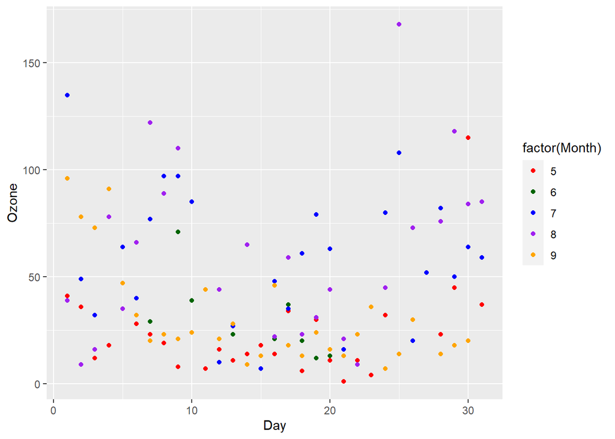

```r
ggplot(data = airquality) +
  geom_point(aes(x = `Day`,
                 y = `Ozone`,
                 colour = factor(`Month`)
                 )
             ) +
  scale_colour_manual(values = c('red',
                                 'dark green',
                                 'blue',
                                 'purple',
                                 'orange'))
```

What if I was desperate to have the colour set as:

- Month 5 - Orange
- Month 6 - Red
- Month 7 - Blue
- Month 8 - Dark Green
- Month 9 - Purple

Now I could just reorder the colours to match the fact that the levels are automatically set by the `factor()` function as: `5, 6, 7, 8, 9`. But a much more robust way would be to name the vector that I use for the colours. For example:

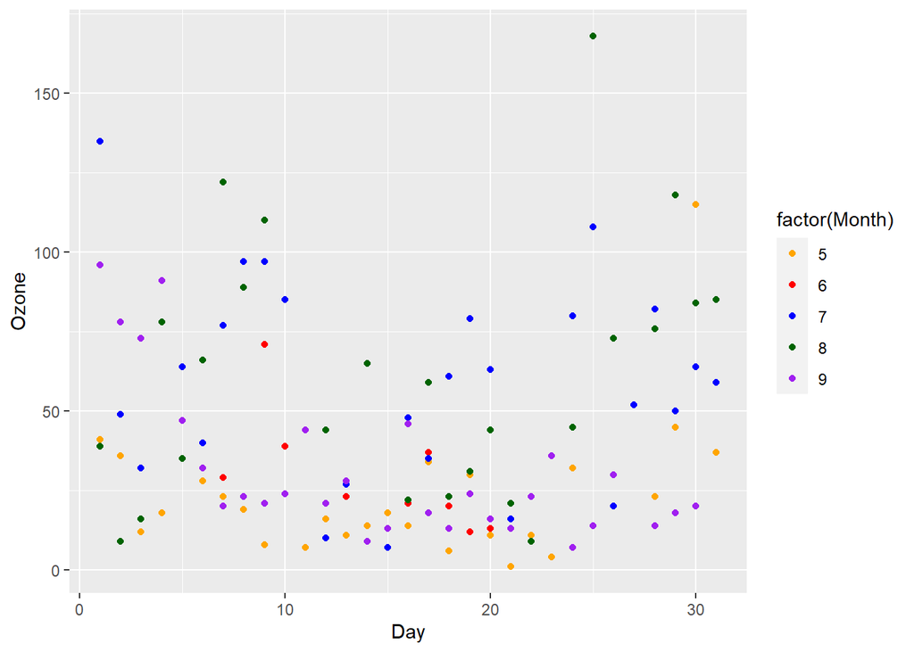

```r
palette_plot <- c("5" = 'orange',
                  "6" = 'red',
                  "7" = 'blue',
                  "8" = 'dark green',
                  "9" = 'purple')

ggplot(data = airquality) +
  geom_point(aes(x = `Day`,
                 y = `Ozone`,
                 colour = factor(`Month`)
                 )
             ) +
  scale_colour_manual(values = palette_plot)
```

We have used the `=` operator to tell R that we want to set a name for the value. The value on the left hand size of the vector for each element is the name, and the value on the right hand side is the value. Let’s see what the output of this vector looks like:

```r
palette_plot
```

```
##            5            6            7            8            9
##     "orange"        "red"       "blue" "dark green"     "purple"
```

You can set the names of an existing vector by using the `setNames()` function in the following manner:

```r
setNames(1:5, c('One', 'Two', '# that comes after Two', 'Four', 'Five'))
```

```
##                    One                    Two # that comes after Two
##                      1                      2                      3
##                   Four                   Five
##                      4                      5
```

Names can be a very useful way to remove the index ordering dependency on vectors. For example, if we want to retrieve the colour for the 8th Month in `palette_plot` , we would need to know the order that R has levelled the `Month` factor in the ggplot. With names we can do this using the name:

```r
palette_plot[4]
```

```
##            8
## "dark green"
```

```r
palette_plot['8']
```

```
##            8
## "dark green"
```

The latter is far more useful, because we know that we are referring to the colour for the 8th month. What if the palette plot got jumbled up?

```r
palette_plot <- palette_plot[sample(1:5, 5)]

palette_plot[4]
```

```
##            8
## "dark green"
```

```r
palette_plot['8']
```

```
##            8
## "dark green"
```

Now we can’t guarantee that the fourth element is the correct way to retrieve the colour for the 8th Month. Using names, we were able to retrieve it regardless of its position.

You can also access multiple values using names:

```r
palette_plot[c('6','7')]
```

```
##      6      7
##  "red" "blue"
```

If you want to drop the name, you can use the `[[` operator rather than the `[` operator. This distinction will become very important shortly, but in this case it will just drop the name

```r
palette_plot[['8']]
```

```
## [1] "dark green"
```

This can be useful if preserving the name will cause problems with operations on other vectors.